# Human Resource Analytics

Srivenkata Srikanth

## Data Acquisition

```r
library(dplyr)
```

```r
library(ggplot2)
library(caret)
library(purrr)
library(devtools)
library(eply)

#train <- read.csv("train.csv")
train= read.csv("C:/Users/Anirud/Desktop/train.csv")
head(train) # view first 5 rows
```

|  | employee_id | department | region | education | gender | recruitment_channel | no_of_trainings | age | previous_year_rating | length_of_service | KPIs_met..80. | awards_won. | avg_training_score | is_promoted |
| --- | --- | --- | --- | --- | --- | --- | --- | --- | --- | --- | --- | --- | --- | --- |
| 1 | 65438 | Sales & Marketing | region_7 | Master's & above | f | sourcing | 1 | 35 | 5 | 8 | 1 | 0 | 49 | 0 |
| 2 | 65141 | Operations | region_22 | Bachelor's | m | other | 1 | 30 | 5 | 4 | 0 | 0 | 60 | 0 |
| 3 | 7513 | Sales & Marketing | region_19 | Bachelor's | m | sourcing | 1 | 34 | 3 | 7 | 0 | 0 | 50 | 0 |
| 4 | 2542 | Sales & Marketing | region_23 | Bachelor's | m | other | 2 | 39 | 1 | 10 | 0 | 0 | 50 | 0 |
| 5 | 48945 | Technology | region_26 | Bachelor's | m | other | 1 | 45 | 3 | 2 | 0 | 0 | 73 | 0 |
| 6 | 58896 | Analytics | region_2 | Bachelor's | m | sourcing | 2 | 31 | 3 | 7 | 0 | 0 | 85 | 0 |

```r
# Dimensions of the Dataset
dim(train)
```

```
## [1] 54808    14
```

```r
# What are the types of our features ?
str(train)
```

```
## 'data.frame':    54808 obs. of  14 variables:
##  $ employee_id         : int  65438 65141 7513 2542 48945 58896 20379 16290 73202 28911 ...
##  $ department          : Factor w/ 9 levels "Analytics","Finance",..: 8 5 8 8 9 1 5 5 1 8 ...
##  $ region              : Factor w/ 34 levels "region_1","region_10",..: 32 15 11 16 19 12 13 28 13 1 ...
##  $ education           : Factor w/ 4 levels "","Bachelor's",..: 4 2 2 2 2 2 2 4 2 4 ...
##  $ gender              : Factor w/ 2 levels "f","m": 1 2 2 2 2 2 1 2 2 2 ...
##  $ recruitment_channel : Factor w/ 3 levels "other","referred",..: 3 1 3 1 1 3 1 3 1 3 ...
##  $ no_of_trainings     : int  1 1 1 2 1 2 1 1 1 1 ...
##  $ age                 : int  35 30 34 39 45 31 31 33 28 32 ...
##  $ previous_year_rating: int  5 5 3 1 3 3 3 3 4 5 ...
##  $ length_of_service   : int  8 4 7 10 2 7 5 6 5 5 ...
##  $ KPIs_met..80.       : int  1 0 0 0 0 0 0 0 0 1 ...
##  $ awards_won.         : int  0 0 0 0 0 0 0 0 0 0 ...
##  $ avg_training_score  : int  49 60 50 50 73 85 59 63 83 54 ...
##  $ is_promoted         : int  0 0 0 0 0 0 0 0 0 0 ...
```

**Factor** stands for categorical variables. The number of **levels** indicates the number of classes per feature.  
**is_promoted** is our target feature.

## Data Cleaning

This section deals with the cleaning operations of our dataset.

### Dealing with Missing Values

```r
# Missing value check
colSums(is.na(train))
```

```
##          employee_id           department               region
##                    0                    0                    0
##            education               gender  recruitment_channel
##                    0                    0                    0
##      no_of_trainings                  age previous_year_rating
##                    0                    0                 4124
##    length_of_service        KPIs_met..80.          awards_won.
##                    0                    0                    0
##   avg_training_score          is_promoted
##                    0                    0
```

So, our dataset has 4124 missing values and all of them lie in **previous_year_rating** .  
But, are all the other features free of missing values?

**In order to check this, we shall plot bar plots for all the categorical features**

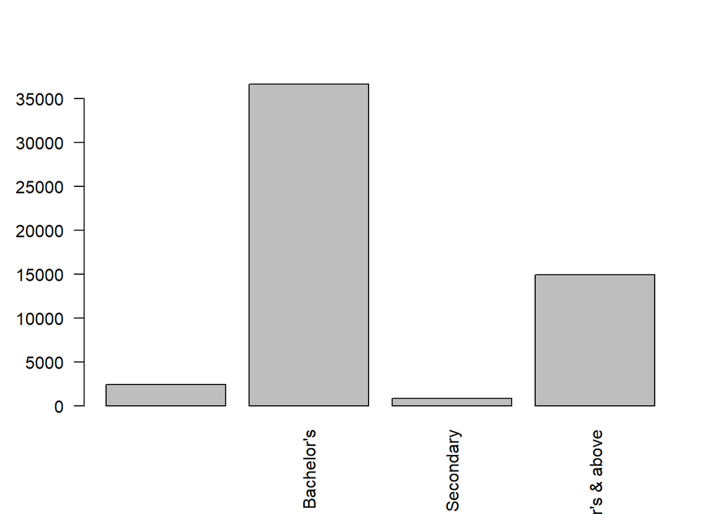

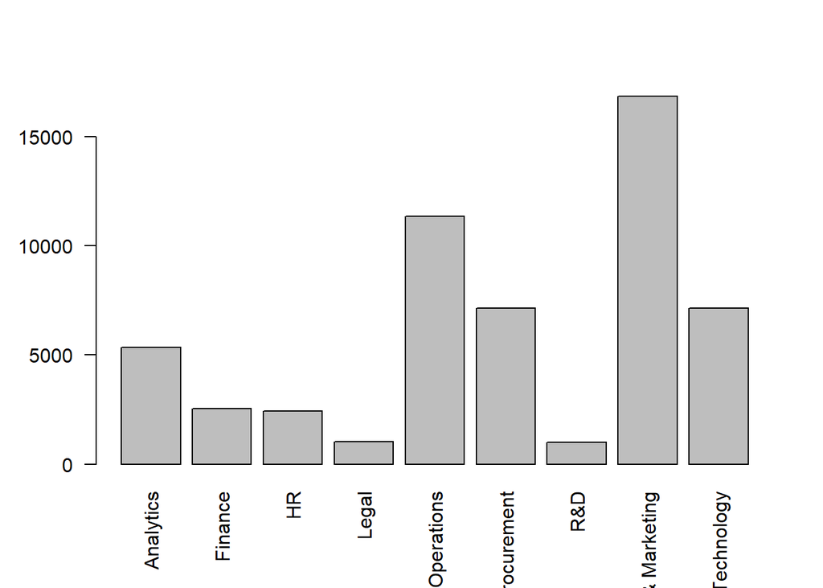

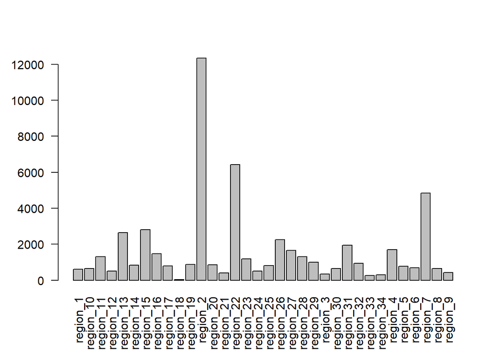

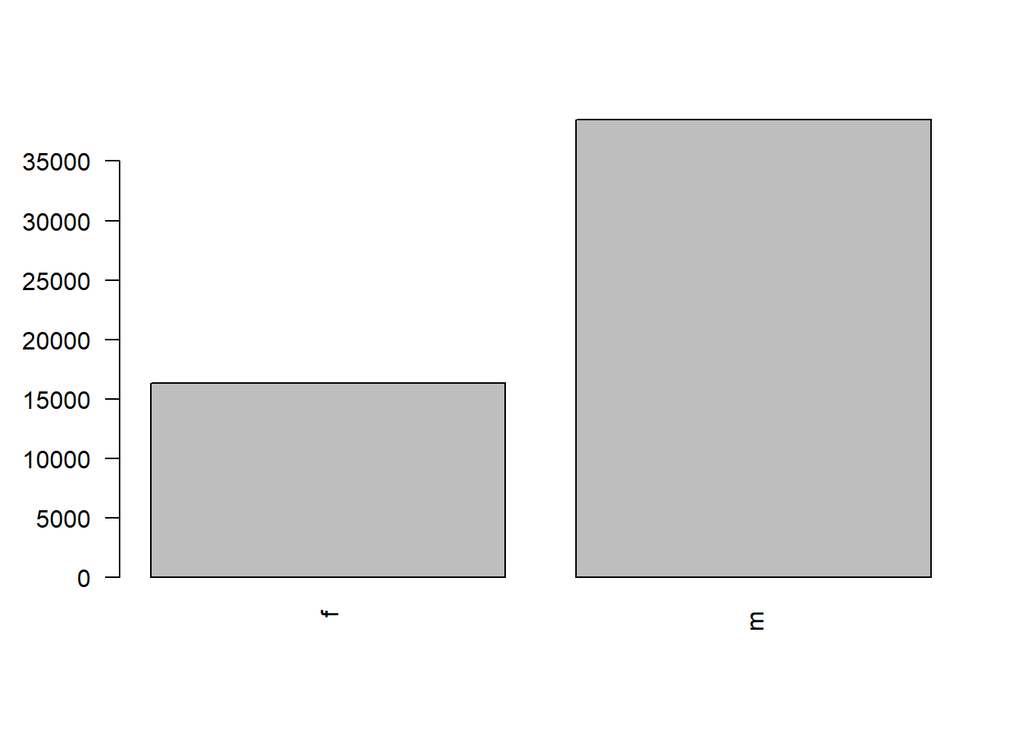

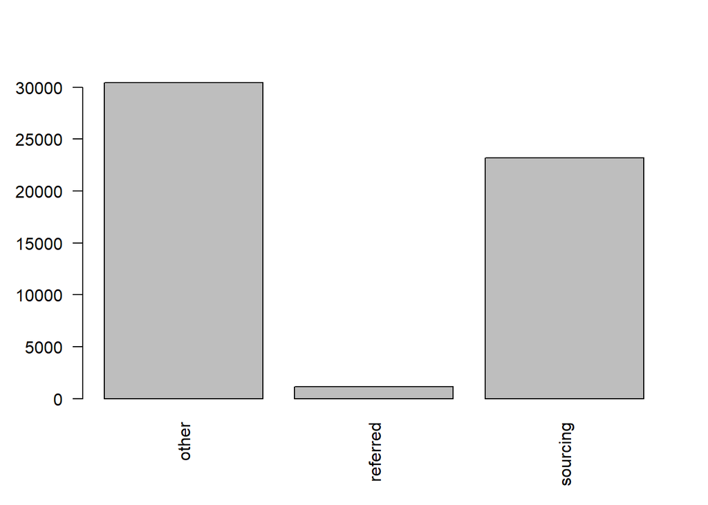

```r
# Plotting the categorical variables
cat_features <- c("education", "department", "region", "gender", "recruitment_channel")
for (f in cat_features){
  counts <- table(train[f])
  barplot(counts, las=2)
}
```

**NOTE** : **education** has missing values. Since the mode is “Bachelor’s”, let’s fill in these values with “Bachelor’s”.

```r
### Fixing the missing values

# Education
train$education[train$education==""] <- "Bachelor's"
# Prev year rating
train$previous_year_rating[is.na(train$previous_year_rating)] <- mean(train$previous_year_rating, na.rm = TRUE)
```

### Types of Features in the Dataset

```r
### Dividing the features into the various types of features
x=map(train,class)

categ=c()
cont=c()

for (i in colnames(train)){
 if(x[[i]]=="factor")
  categ[length(categ)+1]=i
 else
   cont[length(cont)+1]=i
}
cat("Categorical Features: \n",categ,fill=TRUE)
```

```
## Categorical Features:
##  department region education gender
## recruitment_channel
```

```r
cat("Non-categorical Features: \n", cont,fill=TRUE)
```

```
## Non-categorical Features:
##  employee_id no_of_trainings age
## previous_year_rating length_of_service KPIs_met..80. awards_won.
## avg_training_score is_promoted
```

### Feature Type Based Plotting

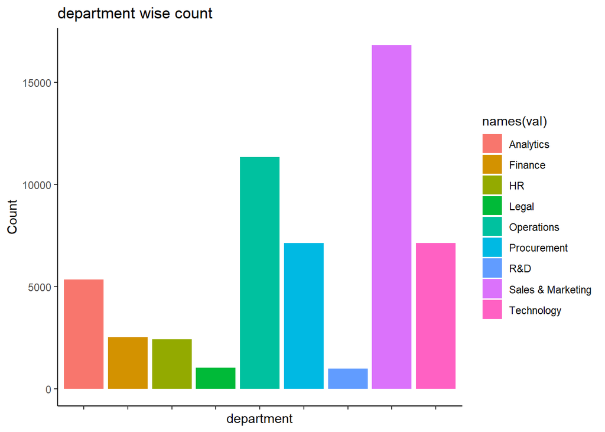

```r
### Count Plots for Categorical Features
cat_plotter<-function(x){
val=table(train[[x]])
values=c()
for(i in val)
  values[length(values)+1]=i

df=data.frame(names(val),values)

ggplot(df,aes(x = names(val), y = values, fill = names(val))) +
  geom_bar(stat = "identity") +
  theme_classic() +
  labs(
    x = x,
    y = "Count",
    title = paste(x,  "wise count"
    )
  ) +
  theme(axis.text.x = element_blank())
}

cat_plotter("department")
```

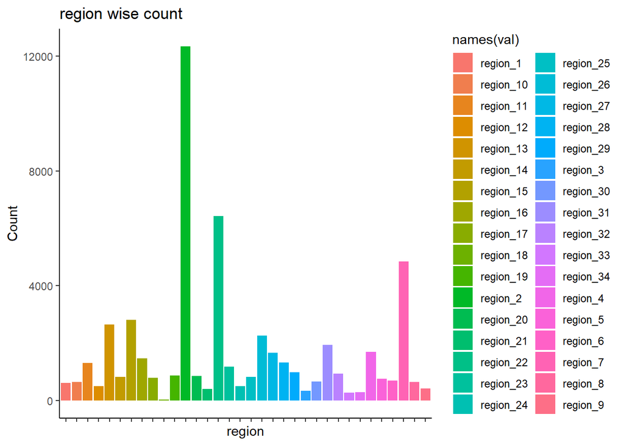

```r
cat_plotter("region")
```

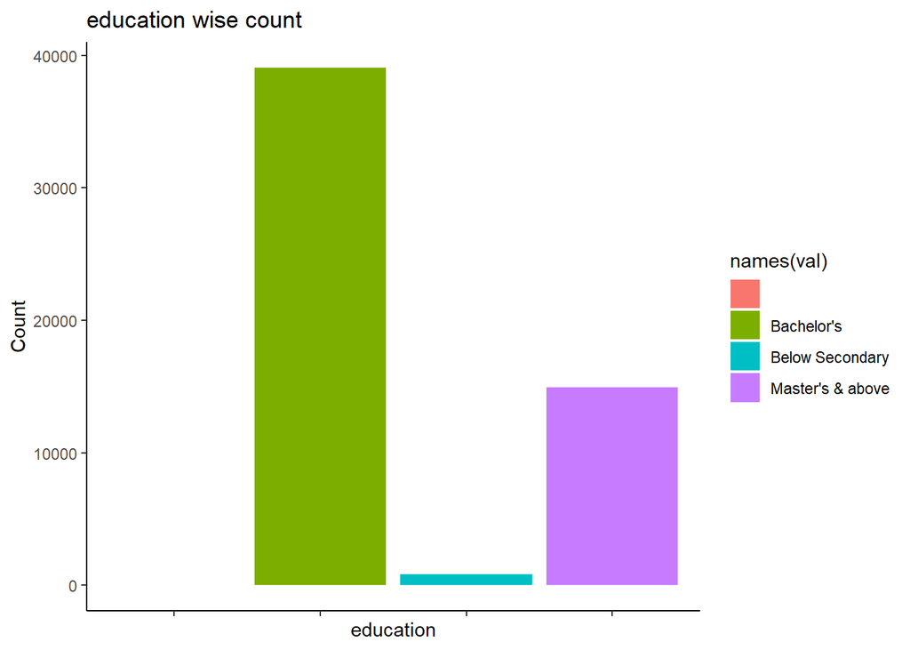

```r
cat_plotter("education")
```

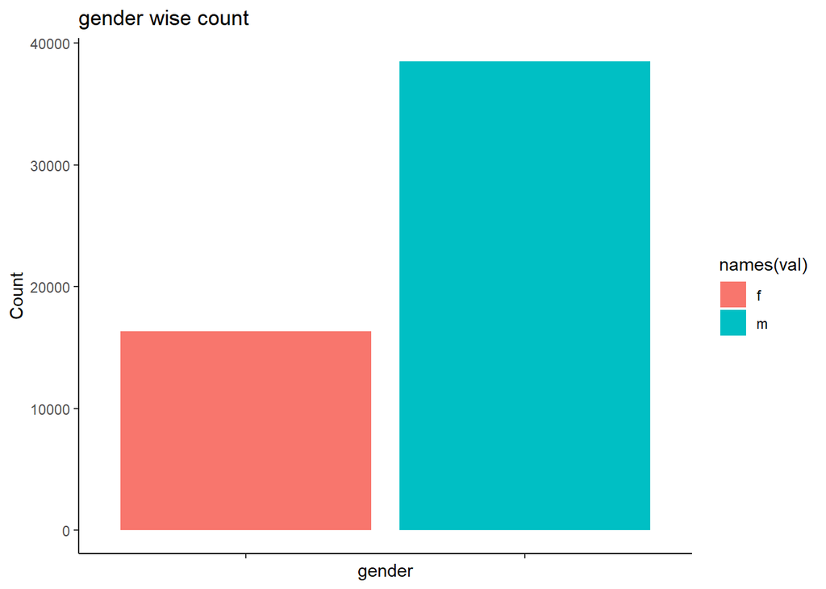

```r
cat_plotter("gender")
```

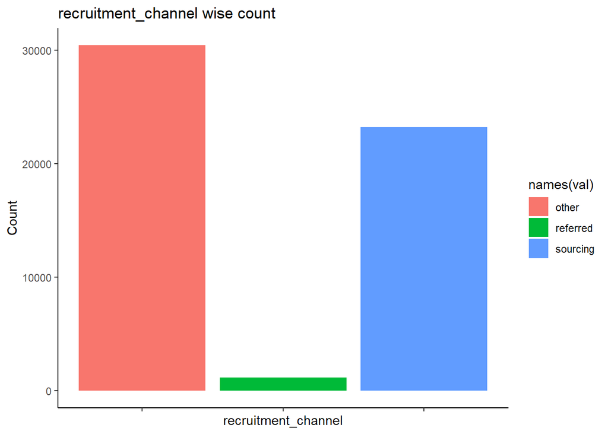

```r
cat_plotter("recruitment_channel")
```

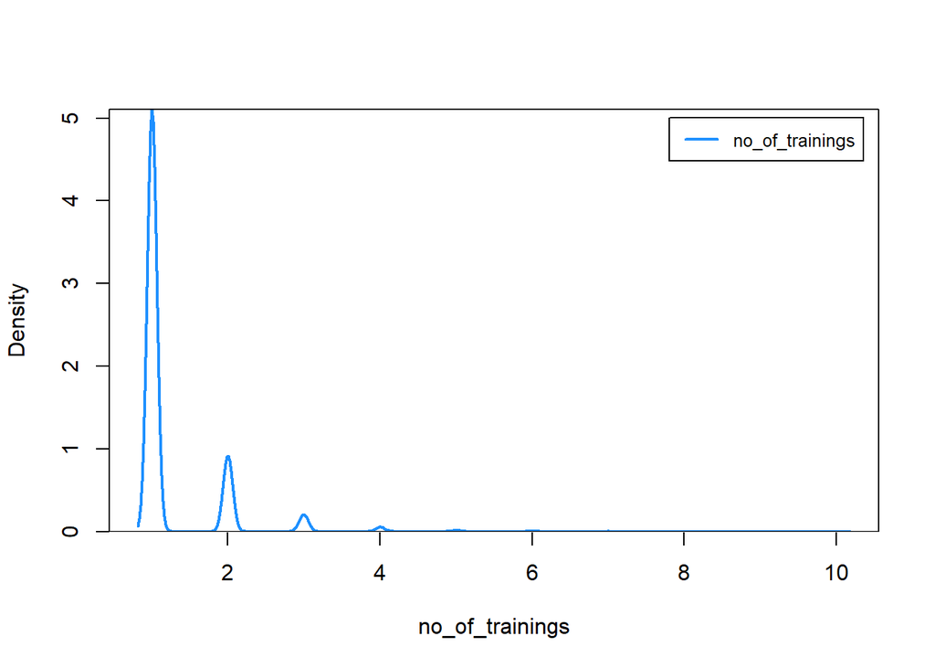

```r
### Density Plots for Continuous Features

cont_plotter<-function(x){
  d <- density(train[[x]]) # returns the density data
  plot(d,col="dodgerblue",xlab=x,main="",lwd=2,yaxs="i")
  legend("topright",legend=x, col="dodgerblue", lty=1:2, cex=0.8,inset = .02,lwd=2)
}

cont_plotter( "no_of_trainings")
```

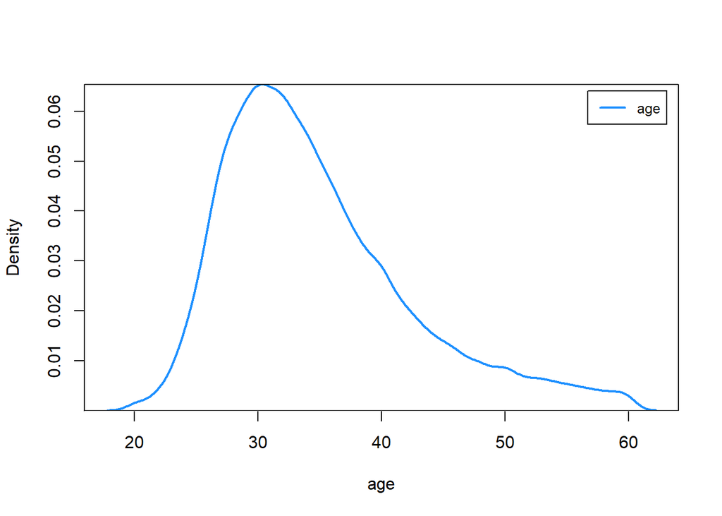

```r
cont_plotter("age")
```

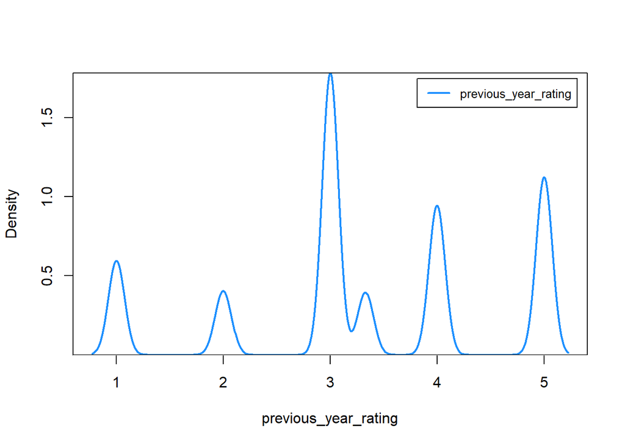

```r
cont_plotter("previous_year_rating")
```

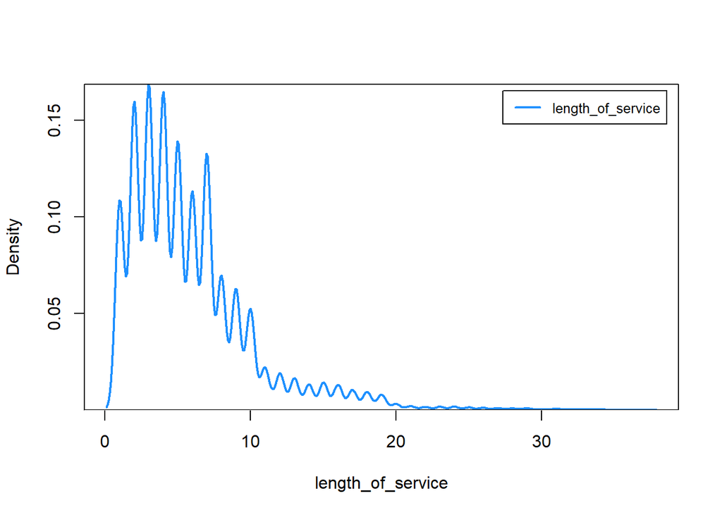

```r
cont_plotter("length_of_service")
```

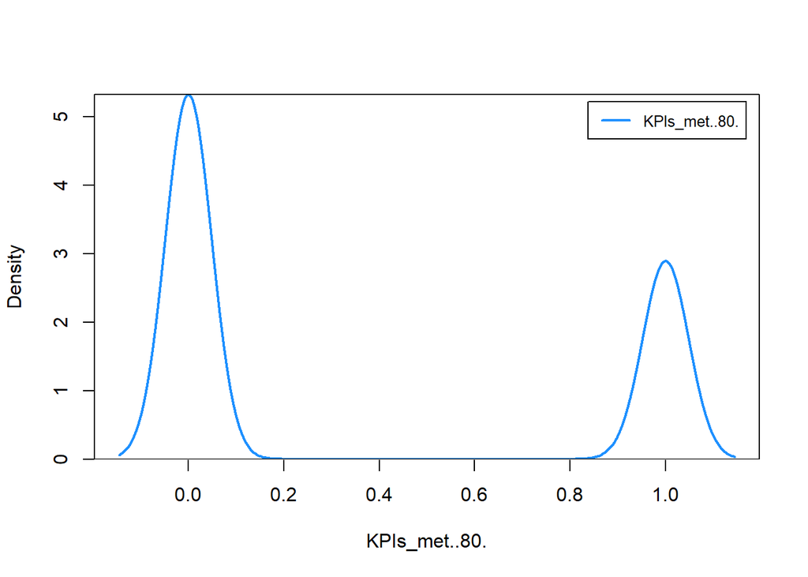

```r
cont_plotter("KPIs_met..80.")
```

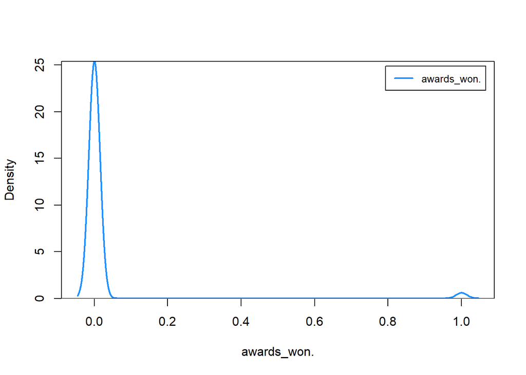

```r
cont_plotter("awards_won.")
```

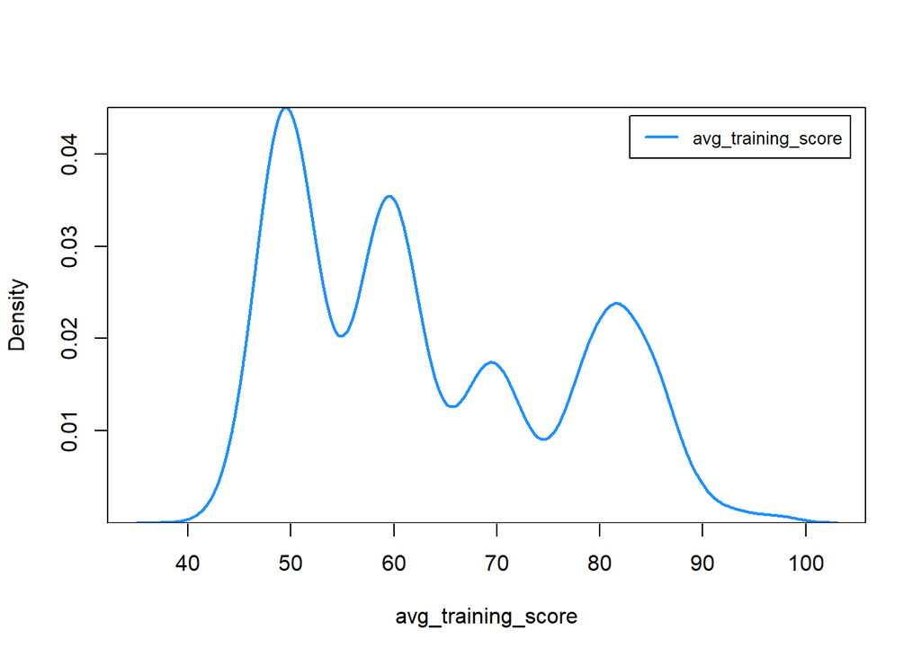

```r
cont_plotter("avg_training_score")
```

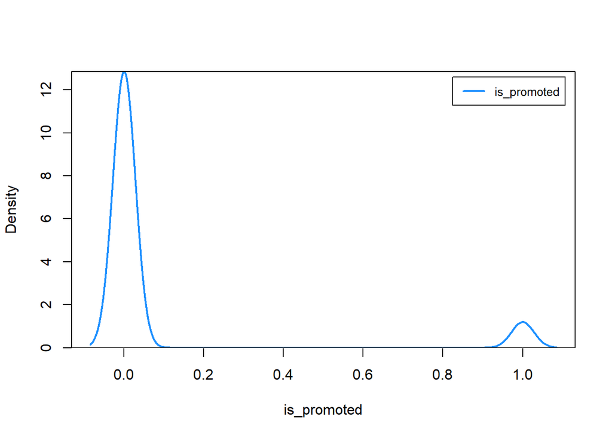

```r
cont_plotter("is_promoted")
```

**NOTE:** The **density plots** provide us with an intuitive understanding about the type of the continuous features. Based on our intuition(solidified by background experiments), we can come to the conclusion that the following are the types of these continous features.

**Ordinal** = previous_year_rating  
**Binary** = KPIs_met..80. , awards_won.  
**Numeric** = no_of_trainings , age , length_of_service , avg_training_score  
**Target** = is_promoted

## Data Preprocessing

This Section deals with feature encoding, feature engineering, dimensinality reduction and related techniques.

### Encoding Data

```r
### Ordinal Encode "education" feature
o <- c("Below Secondary", "Master's & above", "Bachelor's")
n <- factor(train$education, levels=o)
train$education <- as.numeric(n)

### Label Encode "gender" feature
train$gender <- as.numeric(factor(train$gender))

### Ordinal Encode "recruitment_channel" feature
o <- c("other", "sourcing", "referred")
n <- factor(train$recruitment_channel, levels=o)
train$recruitment_channel <- as.numeric(n)

### One hot encode "department" and "region" features
dmy <- dummyVars(" ~ .", data = train)
df <- data.frame(predict(dmy, newdata = train))

### Final DF
head(df)
```

|  | employee_id | department.Analytics | department.Finance | department.HR | department.Legal | department.Operations | department.Procurement | department.R.D | department.Sales...Marketing | department.Technology | region.region_1 | region.region_10 | region.region_11 | region.region_12 | region.region_13 | region.region_14 | region.region_15 | region.region_16 | region.region_17 | region.region_18 | region.region_19 | region.region_2 | region.region_20 | region.region_21 | region.region_22 | region.region_23 | region.region_24 | region.region_25 | region.region_26 | … |
| --- | --- | --- | --- | --- | --- | --- | --- | --- | --- | --- | --- | --- | --- | --- | --- | --- | --- | --- | --- | --- | --- | --- | --- | --- | --- | --- | --- | --- | --- | --- |
| 1 | 65438 | 0 | 0 | 0 | 0 | 0 | 0 | 0 | 1 | 0 | 0 | 0 | 0 | 0 | 0 | 0 | 0 | 0 | 0 | 0 | 0 | 0 | 0 | 0 | 0 | 0 | 0 | 0 | 0 | … |
| 2 | 65141 | 0 | 0 | 0 | 0 | 1 | 0 | 0 | 0 | 0 | 0 | 0 | 0 | 0 | 0 | 0 | 0 | 0 | 0 | 0 | 0 | 0 | 0 | 0 | 1 | 0 | 0 | 0 | 0 | … |
| 3 | 7513 | 0 | 0 | 0 | 0 | 0 | 0 | 0 | 1 | 0 | 0 | 0 | 0 | 0 | 0 | 0 | 0 | 0 | 0 | 0 | 1 | 0 | 0 | 0 | 0 | 0 | 0 | 0 | 0 | … |
| 4 | 2542 | 0 | 0 | 0 | 0 | 0 | 0 | 0 | 1 | 0 | 0 | 0 | 0 | 0 | 0 | 0 | 0 | 0 | 0 | 0 | 0 | 0 | 0 | 0 | 0 | 1 | 0 | 0 | 0 | … |
| 5 | 48945 | 0 | 0 | 0 | 0 | 0 | 0 | 0 | 0 | 1 | 0 | 0 | 0 | 0 | 0 | 0 | 0 | 0 | 0 | 0 | 0 | 0 | 0 | 0 | 0 | 0 | 0 | 0 | 1 | … |
| 6 | 58896 | 1 | 0 | 0 | 0 | 0 | 0 | 0 | 0 | 0 | 0 | 0 | 0 | 0 | 0 | 0 | 0 | 0 | 0 | 0 | 0 | 1 | 0 | 0 | 0 | 0 | 0 | 0 | 0 | … |

```r
### Creating a Validation set

# create a list of 80% of the rows in the original dataset we can use for training
validation_index <- createDataPartition(df$is_promoted, p=0.80, list=FALSE)
# select 20% of the data for validation
validation <- df[-validation_index,]
# use the remaining 80% of data to training and testing the models
dataset <- df[validation_index,]
```

### Binning Age

```r
### Binning age
breaks <- c(20,30,40,50,60)
tags <- c(1,2,3,4)
# train
group_bins <- cut(dataset$age,
                  breaks=breaks,
                  include.lowest=TRUE,
                  right=FALSE,
                  labels=tags)
dataset$age <- as.numeric(group_bins)
# test
group_bins <- cut(validation$age,
                  breaks=breaks,
                  include.lowest=TRUE,
                  right=FALSE,
                  labels=tags)
validation$age <- as.numeric(group_bins)
```

### Dimensionality Reduction

```r
library(caret)
library(mlbench)

### Remove emp id
dataset <- dataset[ , !(names(dataset) %in% c("employee_id"))]
validation <- validation[ , !(names(validation) %in% c("employee_id"))]

### Dealing with Multi-collinearity
correlation <- cor(dataset)
## None of the features have a correlation of greater than 75%

### Ranking Features by importance
# fit_glm = glm(is_promoted~.,dataset,family = "binomial")
# varImp(fit_glm)
```

### Evaluation on 80/20 Split

```r
dataset$is_promoted[dataset$is_promoted==0] <- "No"
dataset$is_promoted[dataset$is_promoted==1] <- "Yes"

# Run algorithms using 10-fold cross validation
control <- trainControl(method="cv", number=10)
metric <- "Accuracy"

# KNN
#set.seed(10)
#fit.knn <- train(is_promoted~., data=dataset, method="knn", metric=metric, trControl=control)

# SVM
#set.seed(10)
#fit.svm <- train(is_promoted~., data=dataset, method="svmRadial", metric=metric, trControl=control)

# Random Forest
#set.seed(10)
#fit.rf <- train(is_promoted~., data=dataset, method="rf", metric=metric, trControl=control)

# Summarize accuracy of models
#results <- resamples(list(knn=fit.knn, svm=fit.svm, rf=fit.rf))
#summary(results)

#print(fit.knn)
library(xgboost)
y=dataset$is_promoted
y[dataset$is_promoted=="No"]=0
y[dataset$is_promoted=="Yes"]=1

y=as.numeric(y)
train_matrix <- xgb.DMatrix(data = as.matrix(dataset[,-54]), label = y)
y=validation$is_promoted
y[validation$is_promoted=="No"]=0
y[validation$is_promoted=="Yes"]=1

y=as.numeric(y)
test_matrix <- xgb.DMatrix(data = as.matrix(validation[,-54]), label = y)
xgb_params <- list("objective" = "multi:softprob",
                   "eval_metric" = "merror",
                   "num_class" = 2)
cv.nfold=10
xgb <- xgb.cv(train_matrix,

               params = xgb_params,

               nfold=cv.nfold,

               data = train_matrix,
               nrounds = 50,

               verbose = FALSE,
               prediction = TRUE
)
bst_model <- xgb.train(params = xgb_params,
                       data = train_matrix,
                       nrounds = 50)
test_pred <- predict(bst_model, newdata = test_matrix)
test_prediction <- matrix(test_pred, nrow = 2,
                          ncol=length(test_pred)/2) %>%
                          t() %>%
                         data.frame() %>%
                           mutate(label = y + 1,
                           max_prob = max.col(., "last"))
## Accuracy for 20 split in original training dataset
confusionMatrix(factor(test_prediction$max_prob),
                factor(test_prediction$label),
                positive = '2',
                mode = "everything")
```

```
## Confusion Matrix and Statistics
##
##           Reference
## Prediction     1     2
##          1 10025   597
##          2    26   313
##
##                Accuracy : 0.9432
##                  95% CI : (0.9387, 0.9474)
##     No Information Rate : 0.917
##     P-Value [Acc > NIR] : < 2.2e-16
##
##                   Kappa : 0.4777
##
##  Mcnemar's Test P-Value : < 2.2e-16
##
##             Sensitivity : 0.34396
##             Specificity : 0.99741
##          Pos Pred Value : 0.92330
##          Neg Pred Value : 0.94380
##               Precision : 0.92330
##                  Recall : 0.34396
##                      F1 : 0.50120
##              Prevalence : 0.08302
##          Detection Rate : 0.02856
##    Detection Prevalence : 0.03093
##       Balanced Accuracy : 0.67068
##
##        'Positive' Class : 2
##
```

### Classification on test data

```r
#-------------------------------------------------------------------
breaks <- c(20,30,40,50,60)
tags <- c(1,2,3,4)
group_bins <- cut(df$age,
                              breaks=breaks,
                                     include.lowest=TRUE,
                                     right=FALSE,
                                     labels=tags)
df$age= as.numeric(group_bins)
df <- df[ , !(names(df) %in% c("employee_id"))]
correlation <- cor(df)

library(xgboost)

label_train=df$is_promoted
label_train=as.numeric(label_train)
train_matrix2 <- xgb.DMatrix(data = as.matrix(df[,-54]), label = label_train)
            #-----------------
test= read.csv("C:/Users/Anirud/Desktop/HRA_test.csv")
colSums(is.na(train))
```

```
##          employee_id           department               region
##                    0                    0                    0
##            education               gender  recruitment_channel
##                    0                    0                    0
##      no_of_trainings                  age previous_year_rating
##                    0                    0                    0
##    length_of_service        KPIs_met..80.          awards_won.
##                    0                    0                    0
##   avg_training_score          is_promoted
##                    0                    0
```

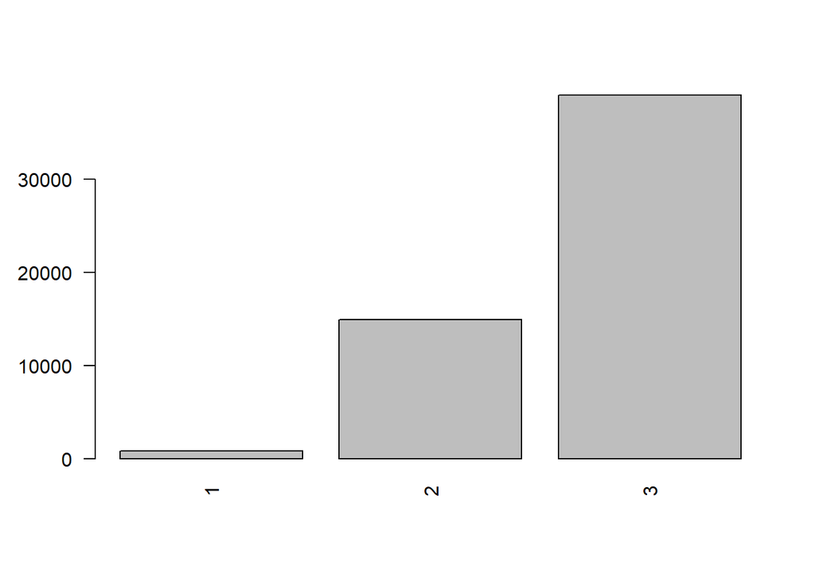

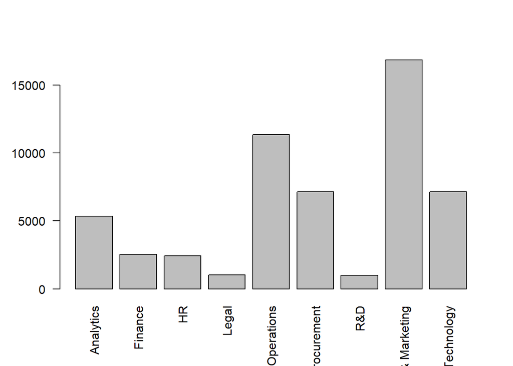

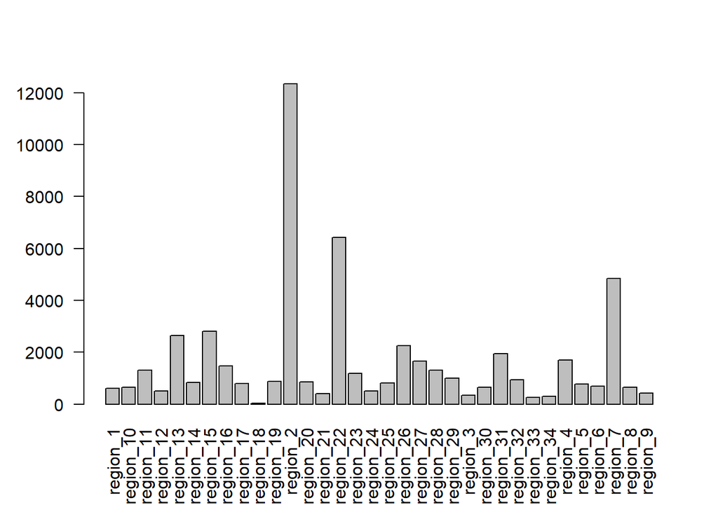

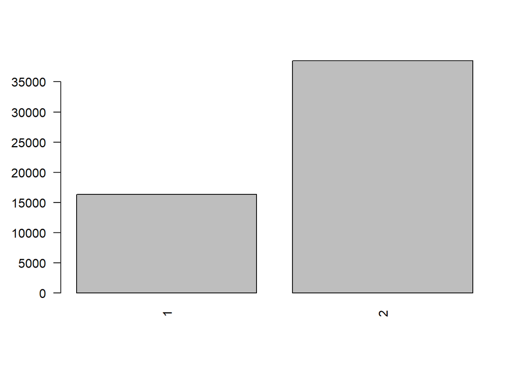

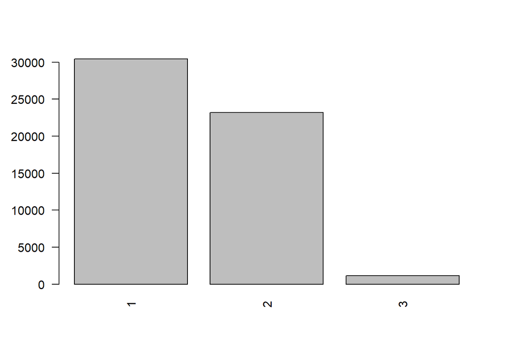

```r
cat_features <- c("education", "department", "region", "gender", "recruitment_channel")
for (f in cat_features){
       counts <- table(train[f])
     barplot(counts, las=2)
 }
```

```r
test$education[test$education==""] <- "Bachelor's"
test$previous_year_rating[is.na(test$previous_year_rating)] <- mean(test$previous_year_rating, na.rm = TRUE)
x=map(test,class)

### Ordinal Encode "education" feature
o <- c("Below Secondary", "Master's & above", "Bachelor's")
n <- factor(test$education, levels=o)
test$education <- as.numeric(n)
 ### Label Encode "gender" feature
   test$gender <- as.numeric(factor(test$gender))

### Ordinal Encode "recruitment_channel" feature
o <- c("other", "sourcing", "referred")
n <- factor(test$recruitment_channel, levels=o)
test$recruitment_channel <- as.numeric(n)

### One hot encode "department" and "region" features
dmy2 <- dummyVars(" ~ .", data = test)
df2 <- data.frame(predict(dmy2, newdata = test))

group_bins <- cut(df2$age,
                                     breaks=breaks,
                                     include.lowest=TRUE,
                                     right=FALSE,
                                     labels=tags)
df2$age= as.numeric(group_bins)
df2 <- df2[ , !(names(df2) %in% c("ï..employee_id"))]
correlation <- cor(df2)

df2$age=as.numeric(df2$age)


xgb_params <- list("objective" = "multi:softmax",
                   "eval_metric" = "merror",

                   "num_class" = 2)
cv.nfold=10

dtrain <- xgb.DMatrix(as.matrix(df[,-54]), label=as.numeric(df$is_promoted))
xgb.DMatrix.save(dtrain, 'xgb.DMatrix.data')
```

```
## [1] TRUE
```

```r
df$is_promoted=as.numeric(df$is_promoted)
xgboost.model <- xgb.cv(

              params = xgb_params,

              nfold=cv.nfold,

              data = dtrain,
              nrounds = 50,

              verbose = FALSE,
              prediction = TRUE
)

bst_model <- xgb.train(params = xgb_params,
                       data =  dtrain,
                       label=as.numeric(df$is_promoted),
                       nrounds = 50)

#                mode = "everything")

testcase_pred2=predict(bst_model,as.matrix(df2))
```